# Final Project

EB

April 17, 2019

## Guthub link

“[Final assignment](https://github.com/l0l0l0l0/ANLY506/tree/master/Code)”

## Data loading

I worked with some of the data from the Gapminder project. Probably should hae figured how to use `wd` function and work around Git, but next time.

```r
# Reading CSV file directly
gm_verbatim <- read.csv("C:/Users/User/Desktop/MyR/Final project/gm.csv")
```

## Libraries

Here goes a list of libraries that I used or the project.

```r
library(ggplot2)   # Graphics package
library(tidyverse) # Package to follow tidy data concept
library(gridExtra) # For nice graph representation
```

## Data intro

The table is tall and almost “tidy”:

1. Population column has data only for every 10 years
2. Values in the population column are recognized as factors
3. There is some data for a weirdo country that only contains values for 10 years. Population does not seem right too. Most likely will drop these values.
4. Potentially, there might be something wrong with “life” data - minimal values start from 1
5. Income column has 2341 missed values (Population column too has many missed values, but since the column is recognized as factors they weren’t count)
6. Minor annoying issue with names - some columns have capital letters, some don’t

```r
head(gm_verbatim)  # Intro to structure of the data
```

```
##       Country Year     life population income     region
## 1 Afghanistan 1800 28.21100    3280000    603 South Asia
## 2 Afghanistan 1801 28.20075               603 South Asia
## 3 Afghanistan 1802 28.19051               603 South Asia
## 4 Afghanistan 1803 28.18026               603 South Asia
## 5 Afghanistan 1804 28.17001               603 South Asia
## 6 Afghanistan 1805 28.15977               603 South Asia
```

```r
str(gm_verbatim)   # Intro to structure of the data
```

```
## 'data.frame':    41284 obs. of  6 variables:
##  $ Country   : Factor w/ 197 levels "Ã…land","Afghanistan",..: 2 2 2 2 2 2 2 2 2 2 ...
##  $ Year      : int  1800 1801 1802 1803 1804 1805 1806 1807 1808 1809 ...
##  $ life      : num  28.2 28.2 28.2 28.2 28.2 ...
##  $ population: Factor w/ 15260 levels "","1,005,328,574",..: 7490 1 1 1 1 1 1 1 1 1 ...
##  $ income    : num  603 603 603 603 603 603 603 603 603 603 ...
##  $ region    : Factor w/ 6 levels "America","East Asia & Pacific",..: 5 5 5 5 5 5 5 5 5 5 ...
```

```r
tail(gm_verbatim, 15) # Some weirdness at the end
```

```
##        Country Year  life population income                region
## 41270 Zimbabwe 2011 51.90   14255592   1626    Sub-Saharan Africa
## 41271 Zimbabwe 2012 54.10   14565482   1750    Sub-Saharan Africa
## 41272 Zimbabwe 2013 56.00   14898092   1773    Sub-Saharan Africa
## 41273 Zimbabwe 2014 57.97   15245855   1773    Sub-Saharan Africa
## 41274 Zimbabwe 2015 60.01   15602751   1801    Sub-Saharan Africa
## 41275   Ã…land 1988 78.90      24229     NA Europe & Central Asia
## 41276   Ã…land 1989 81.00      24416     NA Europe & Central Asia
## 41277   Ã…land 1990 78.25      24579     NA Europe & Central Asia
## 41278   Ã…land 1991 80.00      24719     NA Europe & Central Asia
## 41279   Ã…land 1992 80.83      24834     NA Europe & Central Asia
## 41280   Ã…land 1993 81.80      24950     NA Europe & Central Asia
## 41281   Ã…land 1994 80.63      25066     NA Europe & Central Asia
## 41282   Ã…land 1995 79.88      25183     NA Europe & Central Asia
## 41283   Ã…land 1996 80.00      25301     NA Europe & Central Asia
## 41284   Ã…land 1997 80.10      25419     NA Europe & Central Asia
```

```r
summary(gm_verbatim)  # Basuc descriptive stats
```

```
##                 Country           Year           life
##  Afghanistan        :  216   Min.   :1800   Min.   : 1.00
##  Albania            :  216   1st Qu.:1854   1st Qu.:31.00
##  Algeria            :  216   Median :1908   Median :35.12
##  Angola             :  216   Mean   :1907   Mean   :42.88
##  Antigua and Barbuda:  216   3rd Qu.:1962   3rd Qu.:55.60
##  Argentina          :  216   Max.   :2015   Max.   :84.10
##  (Other)            :39988
##    population        income                              region
##         :25817   Min.   :   142   America                   : 7961
##  121000 :    6   1st Qu.:   883   East Asia & Pacific       : 6256
##  14092  :    6   Median :  1450   Europe & Central Asia     :10468
##  1432000:    6   Mean   :  4571   Middle East & North Africa: 4309
##  229000 :    6   3rd Qu.:  3483   South Asia                : 1728
##  2574000:    6   Max.   :182668   Sub-Saharan Africa        :10562
##  (Other):15437   NA's   :2341
```

```r
names(gm_verbatim) # Column names
```

```
## [1] "Country"    "Year"       "life"       "population" "income"
## [6] "region"
```

```r
sum(is.na(gm_verbatim)) # If there any NA's in numeric data
```

```
## [1] 2341
```

```r
sum(is.na(gm_verbatim$Year))
```

```
## [1] 0
```

```r
sum(is.na(gm_verbatim$life))
```

```
## [1] 0
```

```r
sum(is.na(gm_verbatim$income)) # There we go! 2341 NA's
```

```
## [1] 2341
```

## Quick graphs

This section contains some graphs to make visual assesment of the data structure. Preliminary visualization revealed some interesting patterns that could be interesting for further analysis.

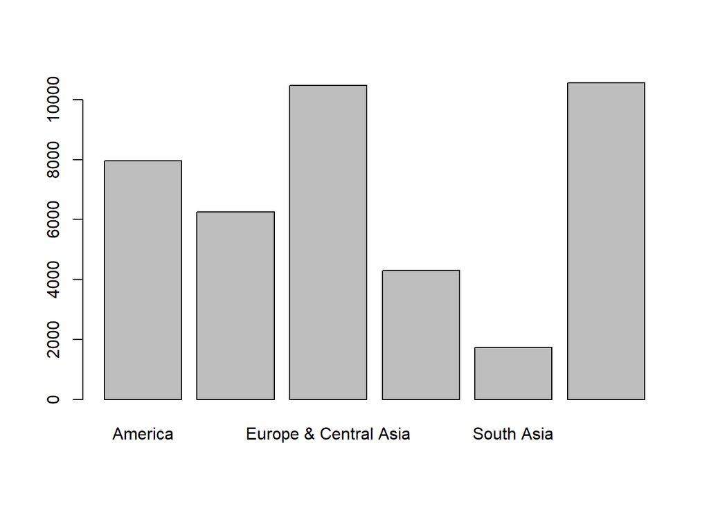

```r
# Simple barplot to see distribution of data for different region.
barplot(table(gm_verbatim$region))
```

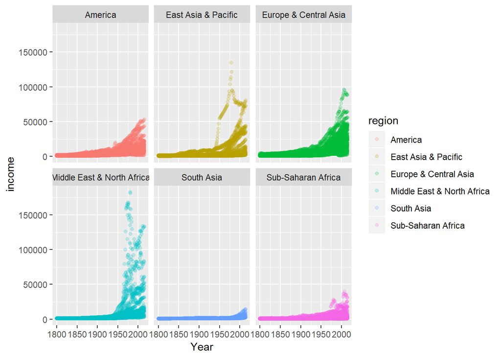

```r
# Plot to see change in income over time, for each region
ggplot(gm_verbatim, aes(x = Year, y = income, col = region, fill = region)) +
  geom_point(alpha = 0.2) +
  facet_wrap(. ~ region)
```

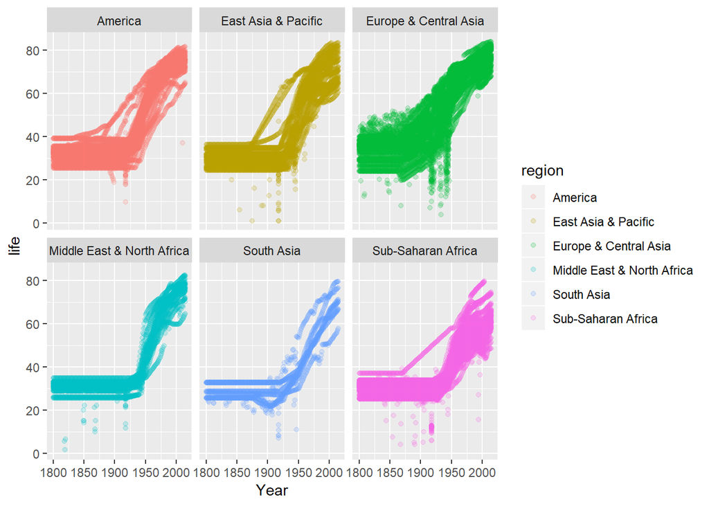

```r
# Plot to see change in life expectancy over the years, for each region
ggplot(gm_verbatim, aes(x = Year, y = life, col = region, fill = region)) +
  geom_point(alpha = 0.2) +
  facet_wrap(. ~ region)
```

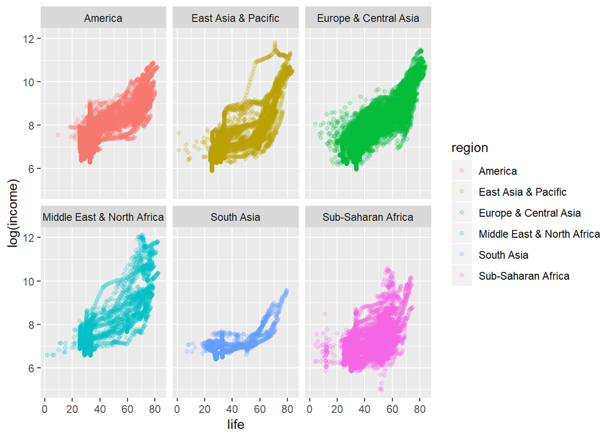

```r
# Classic plot to see correlation between income and life expectancy, for each egion
ggplot(gm_verbatim, aes(x = life, y = log(income), col = region, fill = region)) +
  geom_point(alpha = 0.2) +
  facet_wrap(. ~ region)
```

Observations:

1. South Asia has the least number of records.
2. Some regions have experiened explosive growth in income during the second half of XX century (Middle East, East Asia and, more evenly, Europe)
3. Data for life expectancy is strange - seems like until the beginning of XX century there were next to none records on life expectancy and those missing values were substituted by fixed numbers (see uniform horizontal lines for most of the countries before 1900th)
4. There is some correlation between income and length of life (kind of expected). THe area and the shape of those blobs might tell about dynamics, too.

## Data preparation

Since there were some issues spotted with the original data, I made a few changes.

```r
gmt <- as_tibble(gm_verbatim) # Why not to make a tibble?
gmt$population <- as.numeric(levels(gmt$population))[gmt$population] # Found in the internet - converted factors into numbers
gmt <- gmt[!(gmt$Country =="Ã.land"),] # Deleted the weirdo
```

1. A tibble is considered to be an improvement over traditional data frame. So, I made a tibble from my existing data.
2. Changed the type of the population column to “numeric”. Empty cells became NA’s.
3. Decided to delete that clear outlier with non-legible name

## Graphs

Preliminary work - I made a function that displays large numbers using conventional format for exponents (as accepted by the scientific society).

```r
fancy_scientific <- function(l) {
  l <- format(l, scientific = TRUE) # turn in to character string in scientific notation
  l <- gsub("0e\\+00","0",l) # proper zero display
  l <- gsub("^(.*)e", "'\\1'e", l) # quote the part before the exponent to keep all the digits
  l <- gsub("e\\+","e",l) # remove "+" sign in the exponent notation
  l <- gsub("\\'1[\\.0]*\\'\\%\\*\\%", "", l) # conventional sci-journal format
  l <- gsub("e", "%*%10^", l) # turn the 'e+' into plotmath format
  parse(text=l) # return this as an expression
}
```

## Questions

The following section contains a few questions that I found nteresting to look into.

### How did population change over time?

Now, when Population column is numeric, we can see trends. As an option, NA’s can be substituted with averages of existing values, but it does not seem to be necessary. The graph below shows growth of the population over time. We can spot exponential nature of that growth, as well as a few clear leaders - apparently, India and China. Interestingly, there are a few fast-growing countries that do not have populataion data after ~1975.

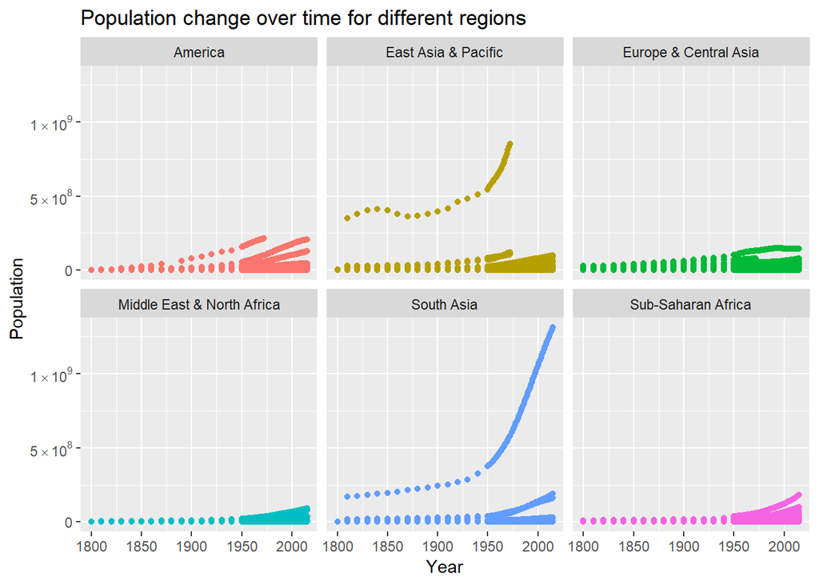

```r
ggplot(gmt, aes(x = Year, y = population, col = region, fill = region)) +
  geom_point() +
  facet_wrap(. ~ region) +
  ggtitle("Population change over time for different regions") +
  scale_y_continuous(name="Population", labels=fancy_scientific) + # Here is the function used to get those neat numbers
  scale_x_continuous(name="Year") +
  theme(legend.position = "none") # Removed legend to improve clarity
```

### The first half of XX century was very hectic, especially for Europe. What was the impact on life expectancy?

We know that the beginning of XX century was marked with several wars, economic downturns and periods of famine. I wanted to see, if data contains indication of those events. I’ve selected a few countries in the European region, semi-arbitrarily. Clearly, WWI and WWII had a huge impact on life expectancy (we can say by looking at major dips around 1915th and 1940th). It’s pretty interesting how Russia cathed up other Europen countries in terms of length of life.

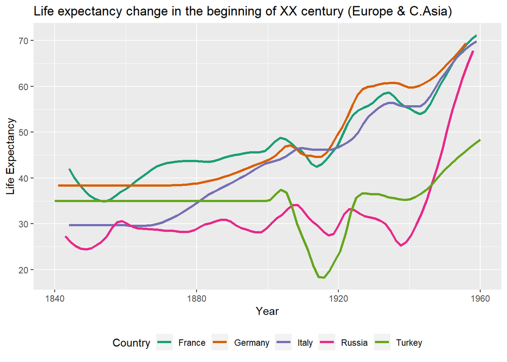

```r
gmt %>%
  filter(Year >= 1840 & Year <= 1960 & Country == c("France","Germany","Italy","Russia","Turkey")) %>%
  ggplot() +
  geom_smooth(mapping = aes(x = Year, y = life, col = Country), se= FALSE, size = 1.2, span = 0.25, na.rm = FALSE) + # Light smoothing to make lines appear less chopped
  scale_colour_brewer(palette = "Dark2") + # Using a better palettes for the output
  ggtitle("Life expectancy change in the beginning of XX century (Europe & C.Asia)") +
  scale_y_continuous(name="Life Expectancy") +
  scale_x_continuous(name="Year") +
  theme(legend.position = "bottom")
```

### Russia’s history is of my particular interest. How did life expectancy in Russia change in XIX-XX centuries?

Speaking about Russia, I decided to take a look on a bit more broader window of time. We can see that rapid growth after WWII quickly reached a plato around 1960-ies. The dip associated to the collapse of the USSR is also easy to spot. Lastly, seems like 1870-ies is the period when more accurate demographic statistics has become available.

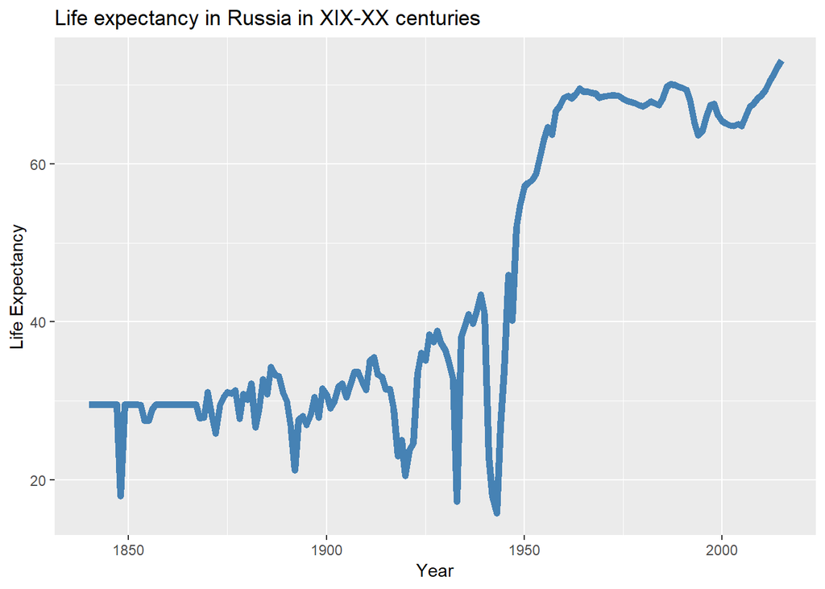

```r
gmt %>% filter(Year >= 1840 & Country == "Russia") %>%
  ggplot() +
  geom_line(mapping = aes(x = Year,y = life), size = 2, color='steelblue') +
  ggtitle("Life expectancy in Russia in XIX-XX centuries") +
  labs(y = "Life Expectancy", x = "Year")
```

### Income

Lastly, I wanted to see changes in economic development across the globe.

```r
MidYears <- c(1850, 1900, 1950, 2000)

#gmt %>%
#  filter(Year == MidYears) %>%
#  ggplot() +
#  geom_histogram(mapping = aes(x = income), binwidth = 1500, color = "blue") +
#  facet_wrap(. ~ Year) +
#  ggtitle("Distribution of income across all countries every 50 years") +
#  scale_y_continuous(name="# of countries") +
#  scale_x_continuous(name="Income") +
#  theme(legend.position = "none")
```

First histogram plot was supposed to reveal a distribution in income globally at 4 reference points in time: 1850, 1900, 1950 and 2000. It became clear that the distribution has very long tail, so that it’s hard to see anything except for a couple of blobs close to zero. So, I decided to artificially make a cutoff at 20,000 and see any patterns.

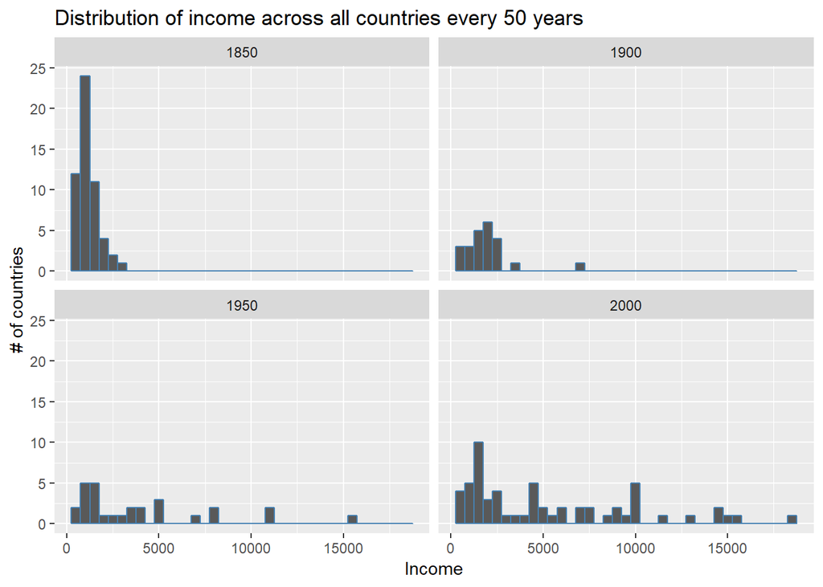

```r
gmt %>%
  filter(Year == MidYears & income <= 20000) %>%
  ggplot() +
  geom_histogram(mapping = aes(x = income), binwidth = 500, color = "steelblue") +
  facet_wrap(. ~ Year) +
  ggtitle("Distribution of income across all countries every 50 years") +
  scale_y_continuous(name="# of countries") +
  scale_x_continuous(name="Income") +
  theme(legend.position = "none")
```

This diagram is more in line with my expectations. In 1850 all countries were sitting together very close to 0. But over time, we can see that the distribution was spreading more and more. So, I became curious, if the same countries have been having spots as the most wealthiest in the world.

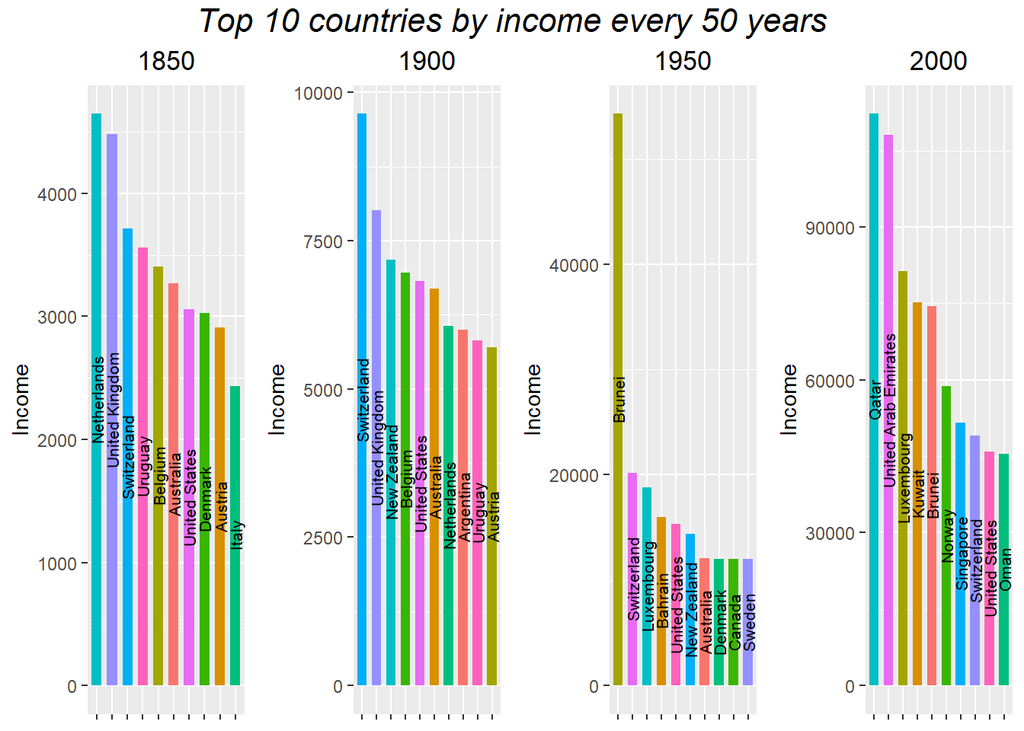

```r
gmt_topI <- gmt %>%
  select(Country, income, Year) %>% # Take only three variables in question
  group_by(Year) %>% # Grouping by year
  top_n(10, wt = income) # For each group = year = I took top 10 countries by income

#==========Below are 4 similar bar plots depicting Top 10 countries at each of our reference points===========

plot1850 <- gmt_topI %>%
  filter(Year == 1850) %>%
  ggplot(aes(x = reorder(Country, -income),y = income, fill = Country)) +
  geom_col(width = 0.65) +
  geom_text(aes(label = Country), position = position_stack(vjust = 0.5), size = 2.75, colour = 'black', angle = 90) +
  ggtitle("1850") +
  theme(plot.title = element_text(hjust = 0.5)) +
  scale_y_continuous(name = "Income") +
  theme(axis.title.x = element_blank()) +
  theme(axis.text.x = element_blank()) +
  theme(legend.position = "none")

plot1900 <- gmt_topI %>%
  filter(Year == 1900) %>%
  ggplot(aes(x = reorder(Country, -income),y = income, fill = Country)) +
  geom_col(width = 0.65) +
  geom_text(aes(label = Country), position = position_stack(vjust = 0.5), size = 2.75, colour = 'black', angle = 90) +
  ggtitle("1900") +
  theme(plot.title = element_text(hjust = 0.5)) +
  scale_y_continuous(name = "Income") +
  theme(axis.title.x = element_blank()) +
  theme(axis.text.x = element_blank()) +
  theme(legend.position = "none")

plot1950 <- gmt_topI %>%
  filter(Year == 1950) %>%
  ggplot(aes(x = reorder(Country, -income),y = income, fill = Country)) +
  geom_col(width = 0.65) +
  geom_text(aes(label = Country), position = position_stack(vjust = 0.5), size = 2.75, colour = 'black', angle = 90) +
  ggtitle("1950") +
  theme(plot.title = element_text(hjust = 0.5)) +
  scale_y_continuous(name = "Income") +
  theme(axis.title.x = element_blank()) +
  theme(axis.text.x = element_blank()) +
  theme(legend.position = "none")

plot2000 <- gmt_topI %>%
  filter(Year == 2000) %>%
  ggplot(aes(x = reorder(Country, -income),y = income, fill = Country)) +
  geom_col(width = 0.65) +
  geom_text(aes(label = Country), position = position_stack(vjust = 0.5), size = 2.75, colour = 'black', angle = 90) +
  ggtitle("2000") +
  theme(plot.title = element_text(hjust = 0.5)) +
  scale_y_continuous(name = "Income") +
  theme(axis.title.x = element_blank()) +
  theme(axis.text.x = element_blank()) +
  theme(legend.position = "none")

grid.arrange(plot1850, plot1900, plot1950, plot2000, ncol = 4,top = textGrob("Top 10 countries by income every 50 years", gp = gpar(fontsize = 16, font = 3))) # This command allows to put all four graps next to each other for easier comparison.
```

Well, this graph can still be improved in many ways, but I decided not to go down the rabbit hole :)

Findings:

1. European countries clearly dominated for a very long time.
2. Income of the leading countries grew 2-3x every 50 years.
3. Somehow, Uruguay made it to the list two times - 1850 and 1900 (Big surprise)
4. In the mid of XX century, Middle East countries started taking over spots in the Top list - presumably, because of oil trade.
5. US always were among the top (always = for the period of observation), but never made it to 1-3 places.

By 1950, Brunei was very close to the point of 60k in income. So, I wanted to look when and what countries have reached that mark and what has happened over time.

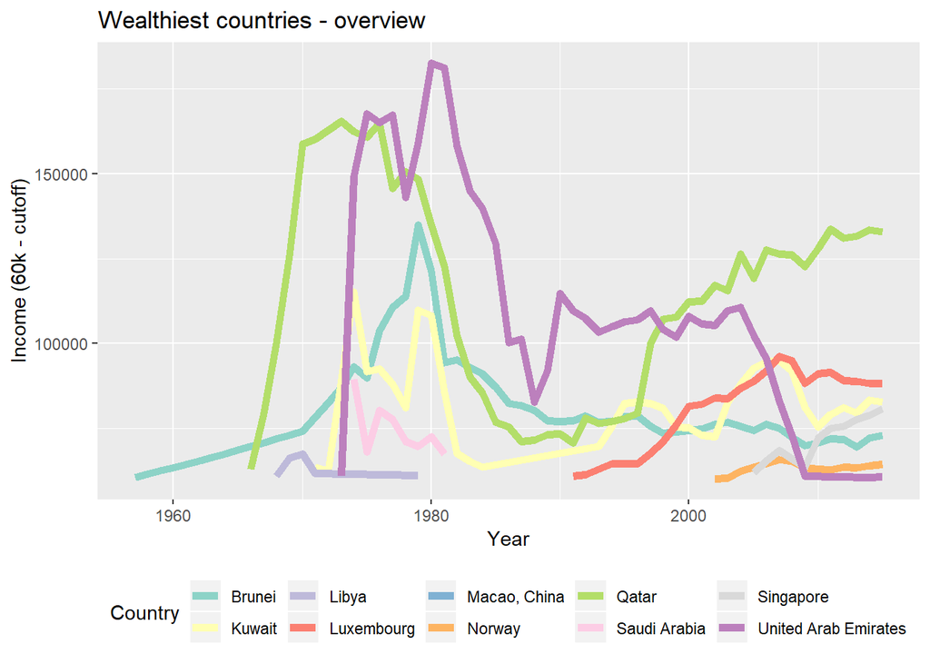

```r
gmt %>%
  filter(income > 60000) %>%
  ggplot(aes(x = Year, y = income, color = Country)) +
  geom_line(size = 2) +
  scale_colour_brewer(palette = "Set3") +
  ggtitle("Wealthiest countries - overview") +
  labs(x="Year", y="Income (60k - cutoff)") +
  theme(legend.position = "bottom")
```

Clearly, the golden era for those Middle East countries happened around 1970-1980-ies. Huge income, phenomenal growth rate and not less phenomenal decline. Nonetheless, those middle-eastern countries are still in the top, so we will see how the history will unwrap.

Finally, I wanted to understand the current state of the world economy (current - as data permits).

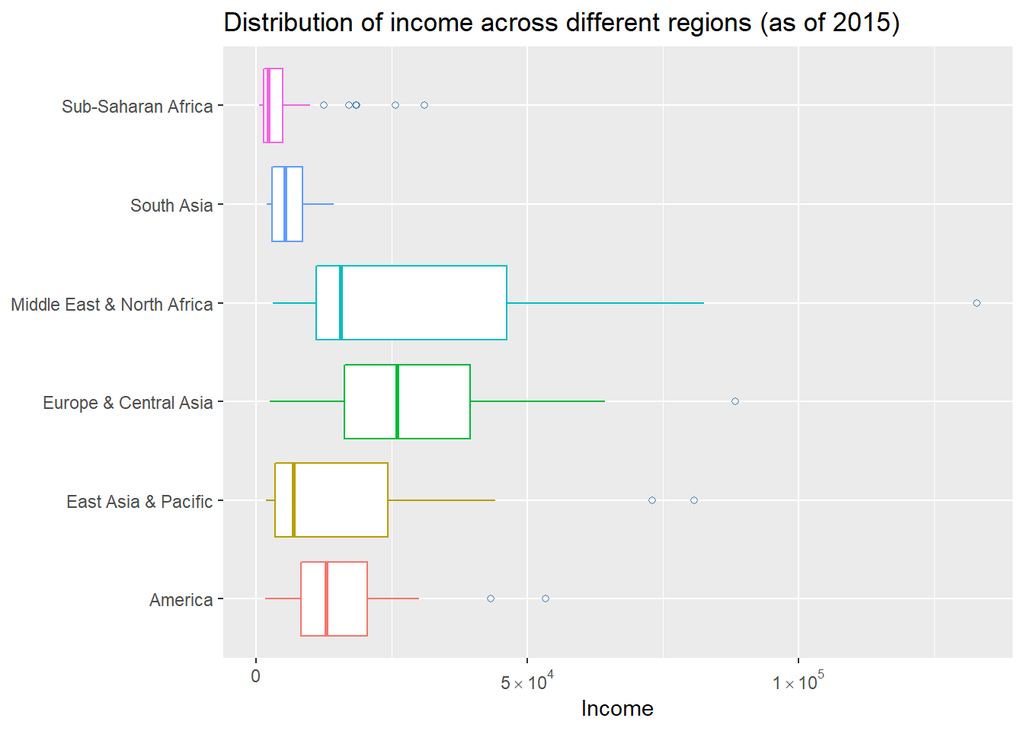

```r
gmt %>%
  filter(Year == 2015) %>%
  arrange(region) %>%
  ggplot(aes(x = region, y = income, color = region)) +
  geom_boxplot(outlier.colour = "steelblue", outlier.shape = 1) +
  coord_flip() +
  ggtitle("Distribution of income across different regions (as of 2015)") +
  scale_y_continuous(name="Income", labels=fancy_scientific) +
  theme(axis.title.y = element_blank()) +
  theme(legend.position = "none")
```

As we can see, Africa is still very poor, with a handful of countries managed to live well, though. Middle East, as we noted, is rich but has the most disperse distribution of income, with a median below that of Europe. Europe has the most balanced distribution, thanks to EU, apparently.